# A3_MoreOnGraphs

Saransh Rakshak

### Setup

```r
# Load packages needed
library(tidyverse)
library(openintro)
library(visdat)
```

```r
# Create condensed dataframe loans
loans <- loans_full_schema %>%
  select(loan_amount, interest_rate, term, grade,
         state, annual_income, homeownership, debt_to_income)

glimpse(loans)
```

```
## Rows: 10,000
## Columns: 8
## $ loan_amount    <int> 28000, 5000, 2000, 21600, 23000, 5000, 24000, 20000, 20…
## $ interest_rate  <dbl> 14.07, 12.61, 17.09, 6.72, 14.07, 6.72, 13.59, 11.99, 1…
## $ term           <dbl> 60, 36, 36, 36, 36, 36, 60, 60, 36, 36, 60, 60, 36, 60,…
## $ grade          <fct> C, C, D, A, C, A, C, B, C, A, C, B, C, B, D, D, D, F, E…
## $ state          <fct> NJ, HI, WI, PA, CA, KY, MI, AZ, NV, IL, IL, FL, SC, CO,…
## $ annual_income  <dbl> 90000, 40000, 40000, 30000, 35000, 34000, 35000, 110000…
## $ homeownership  <fct> MORTGAGE, RENT, RENT, RENT, RENT, OWN, MORTGAGE, MORTGA…
## $ debt_to_income <dbl> 18.01, 5.04, 21.15, 10.16, 57.96, 6.46, 23.66, 16.19, 3…
```

#### Visual of types of data in `loans` dataframe

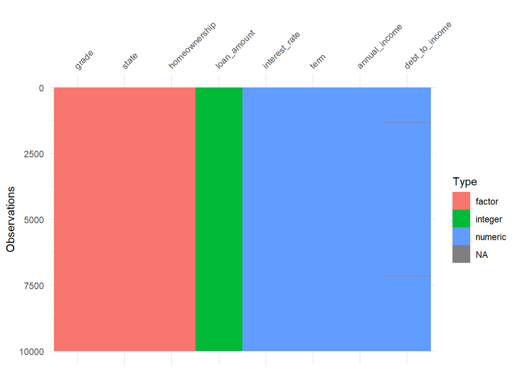

```r
vis_dat(loans)
```

#### Using the `loans` dataframe create a histogram for `interest_rate`. The histogram should have an appropriate amount of bins. Be sure to provide an apprppriate title and axis labels.

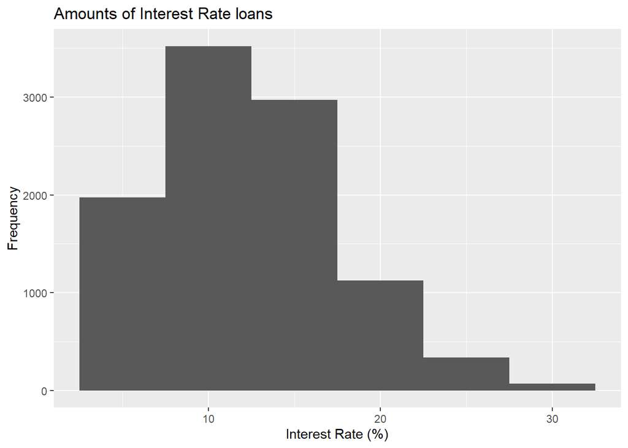

```r
ggplot(loans, aes(x = interest_rate)) +
  geom_histogram(binwidth = 5) +
  labs(
    x = "Interest Rate (%)",
    y = "Frequency",
    title = "Amounts of Interest Rate loans"
  )
```

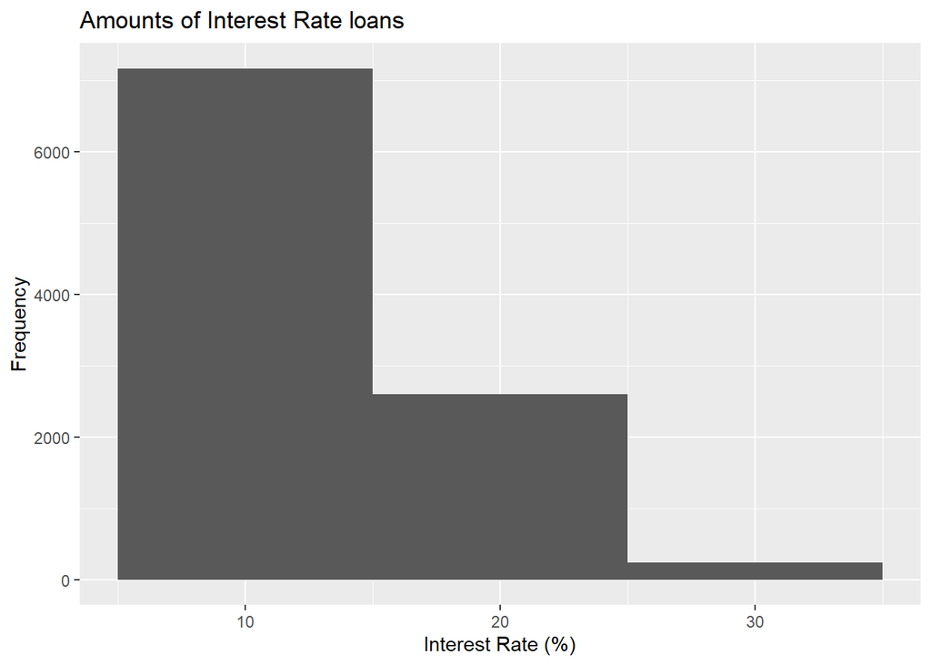

```r
ggplot(loans, aes(x = interest_rate)) +
  geom_histogram(binwidth = 10) +
  labs(
    x = "Interest Rate (%)",
    y = "Frequency",
    title = "Amounts of Interest Rate loans"
  )
```

#### Using the `loans` dataframe, create a facet histogram of `interest_rate` broken down by `grade`.

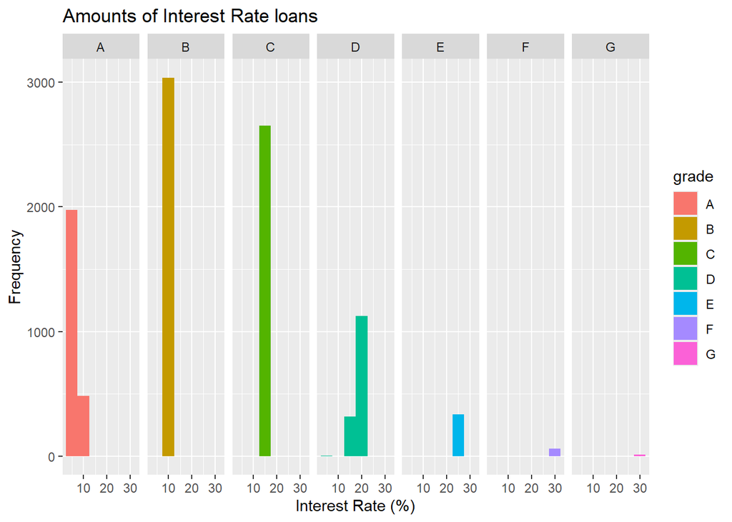

```r
ggplot(loans, aes(x = interest_rate, fill = grade)) +
  geom_histogram(binwidth = 5) +
  labs(
    x = "Interest Rate (%)",
    y = "Frequency",
    title = "Amounts of Interest Rate loans"
  ) +
  facet_grid(~grade)
```

#### Using the `loans` dataframe, create a density plot of `interest_rate` separated by `grade`. Use an appropriate adjustment value. Use appropriate titles and labels.

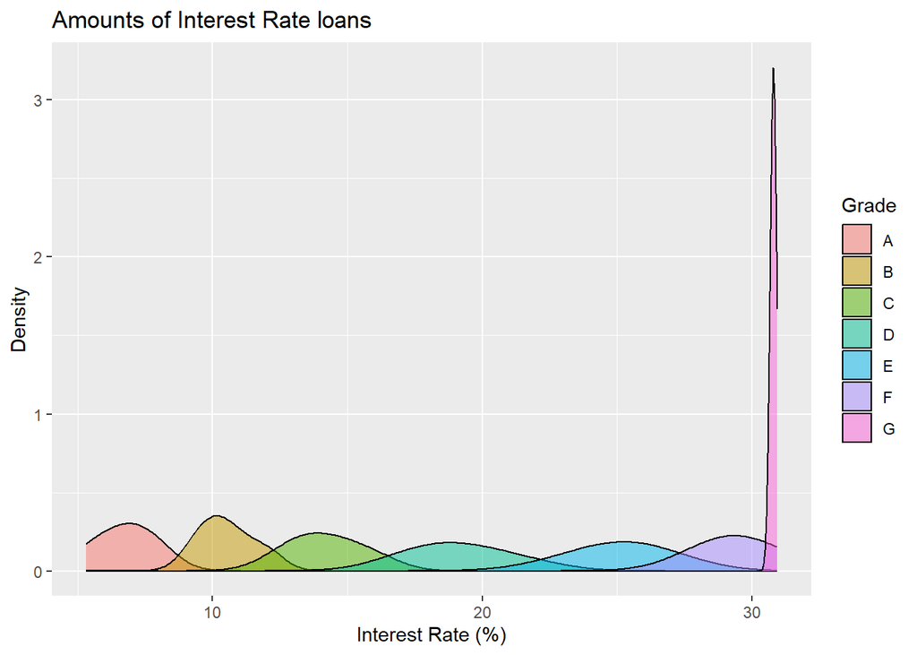

```r
ggplot(loans, aes(x = interest_rate,
                  fill = grade)) +
  geom_density(adjust = 5,
               alpha = 0.5) +
  labs(
    x = "Interest Rate (%)",
    y = "Density",
    title = "Amounts of Interest Rate loans",
    fill = "Grade"
  )
```

#### Do you notice anything unusual about this graph? Explain.

- Yes. For grades A-F there is distribution spread across a range of interest rates. But, for grade G, there is little to no spread, this may likely be the result of those in grade G receiving a shared, fixed value interest rate. This is also reflected in our facet histogram above and our boxplot below, having values for only one specific interest rate percentage.

#### Using the loans dataframe, create boxplots of `interest_rate` sepearted by `grade`, coloring each box a different color based on `grade`. Use appropriate labels and titles.

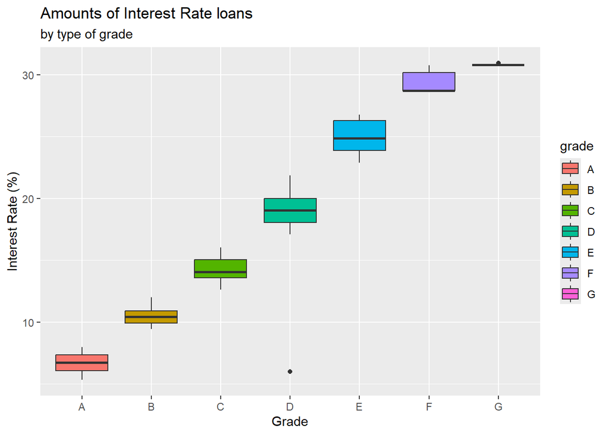

```r
ggplot(loans, aes(x = grade,
                  y = interest_rate, fill=grade)) +
  geom_boxplot() +
  labs(
    x = "Grade",
    y = "Interest Rate (%)",
    title = "Amounts of Interest Rate loans",
    subtitle = "by type of grade"
  )
```

#### Using the loans dataframe create a hexplot of `loan_amount` vs. `interest_rate` for `grade` (Hint: use the `fill` argument). Please provide appropriate title(s) and labels.

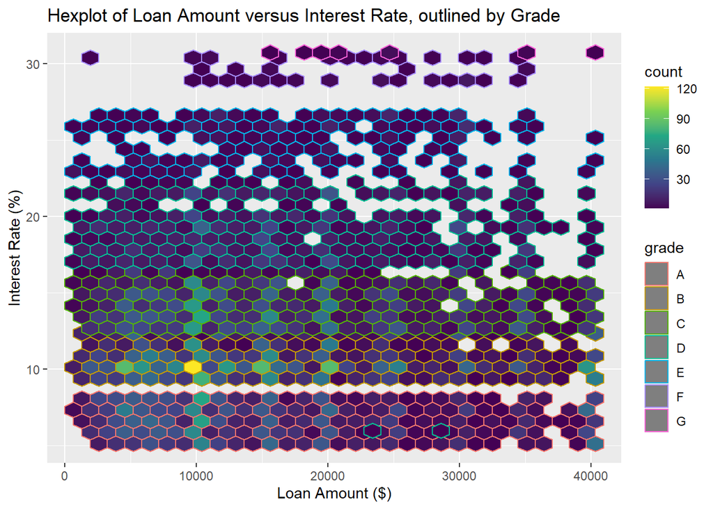

```r
ggplot(loans, aes(x = loan_amount, y = interest_rate, color = grade), fill = grade) +
  geom_hex() +
  labs(
    x = "Loan Amount ($)",
    y = "Interest Rate (%)",
    title = "Hexplot of Loan Amount versus Interest Rate, outlined by Grade"
  ) +
  scale_fill_viridis_c()
```

#### Using the loans dataframe and the idea that you can filter within the ggplot function, create a hexplot of `loan_amount` vs. `interest_rate` for `grade` values A thru F (exclude grade G). Please provide appropriate title(s) and labels.

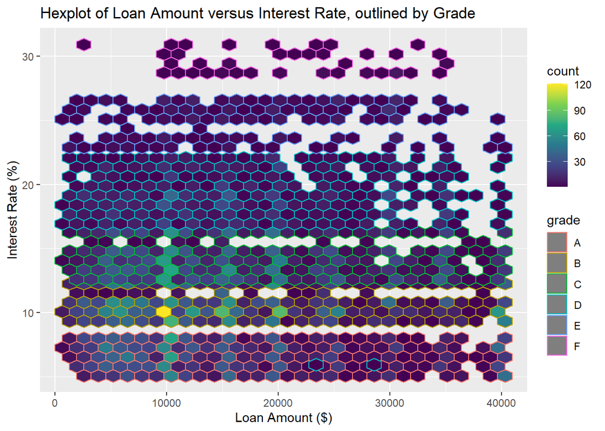

```r
ggplot(loans %>% filter(grade != "G"),
       aes(x = loan_amount, y = interest_rate, color = grade), fill = grade) +
  geom_hex() +
  labs(
    x = "Loan Amount ($)",
    y = "Interest Rate (%)",
    title = "Hexplot of Loan Amount versus Interest Rate, outlined by Grade"
  ) +
  scale_fill_viridis_c()
```

#### Using the `loans` dataframe, create a segmented bar chart of `state` segmented by `homeownership`. The bars should be horizontal (not vertical) and the length of the bars should be the count for each state. The graph should have appropriate titles, and labels.

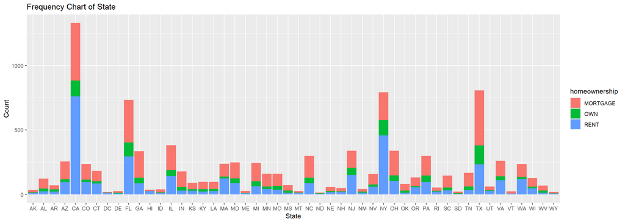

```r
ggplot(loans, aes(x = state,
                  fill = homeownership)) +
  geom_bar() +
    labs(
    x="State",
    y= "Count",
    title= "Frequency Chart of State"
  )
```